# 1US0 TYR Ring_0_0.3_12_Density

## 3d view of density

xyz

yzx

zxy

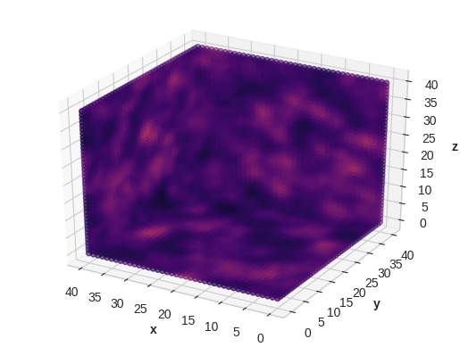

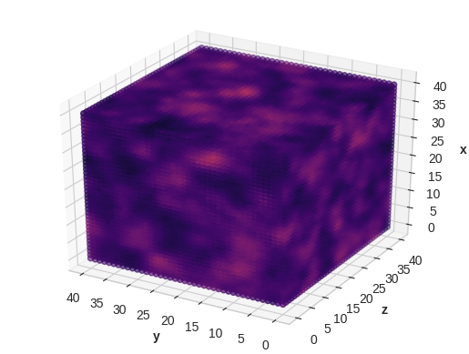

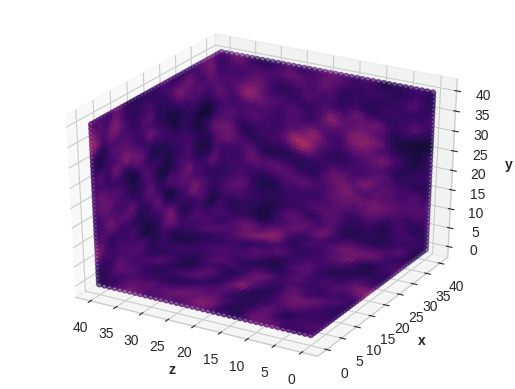

## Slices along x,y and z

Sliced x-wise

Sliced y-wise

Sliced z-wise

0/41

0/41

0/41

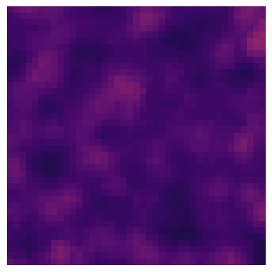

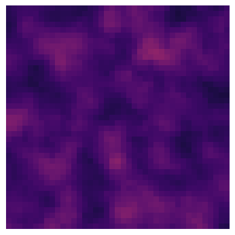

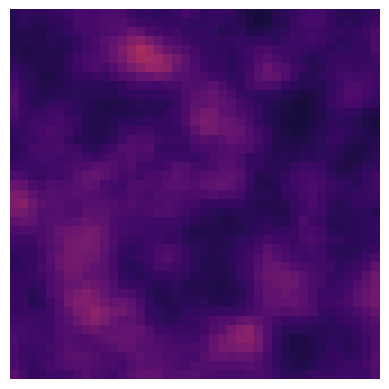

1/41

1/41

1/41

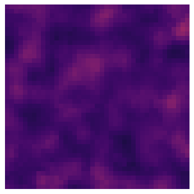

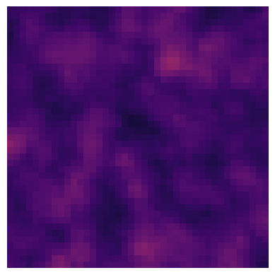

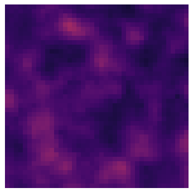

2/41

2/41

2/41

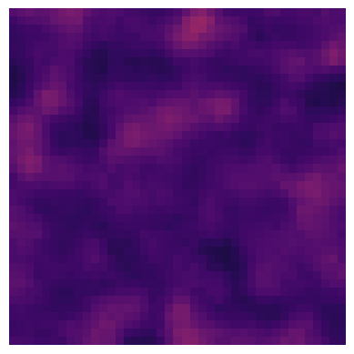

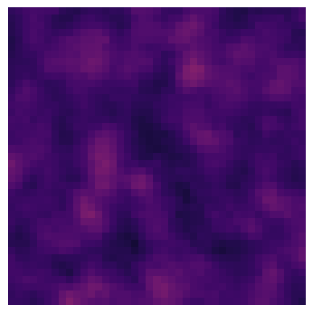

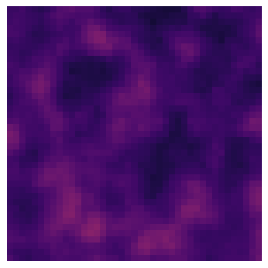

3/41

3/41

3/41

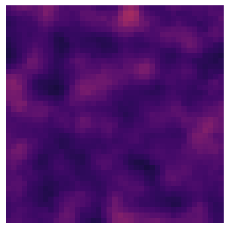

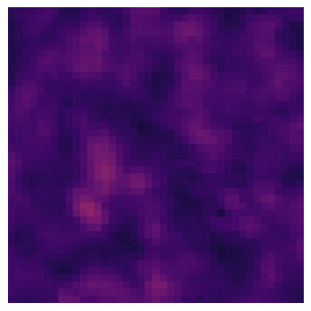

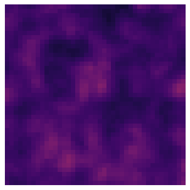

4/41

4/41

4/41

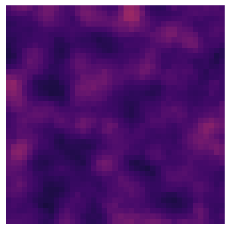

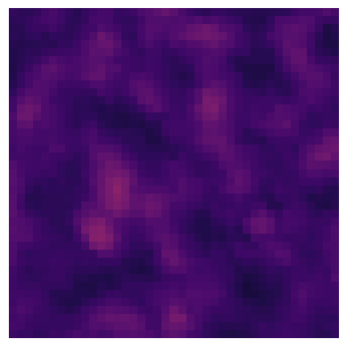

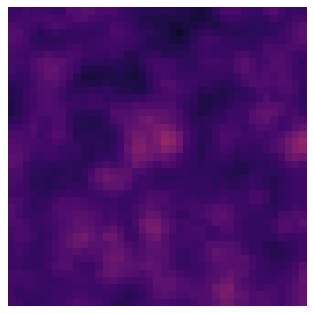

5/41

5/41

5/41

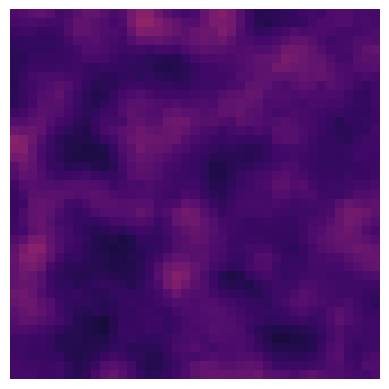

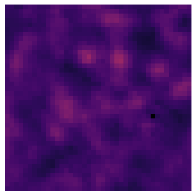

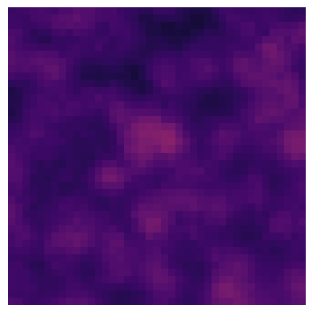

6/41

6/41

6/41

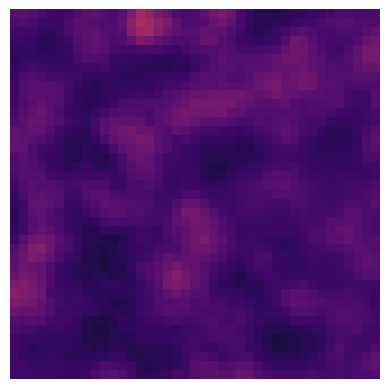

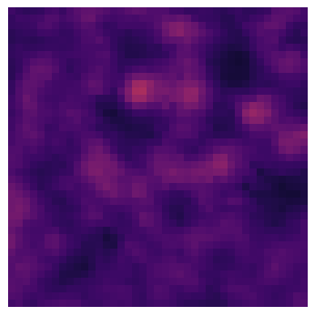

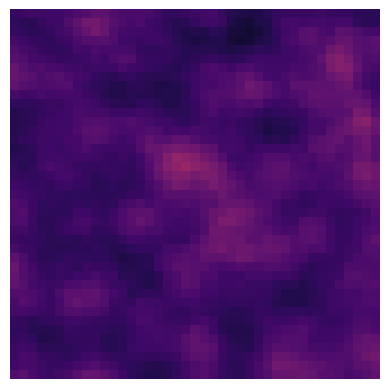

7/41

7/41

7/41

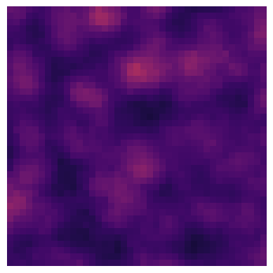

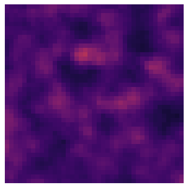

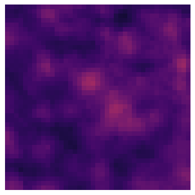

8/41

8/41

8/41

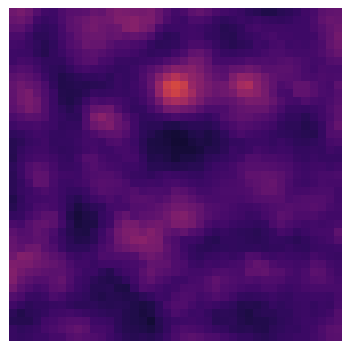

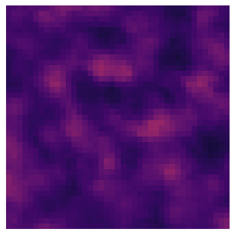

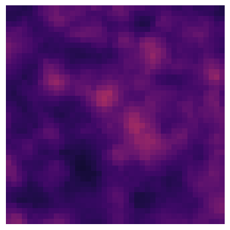

9/41

9/41

9/41

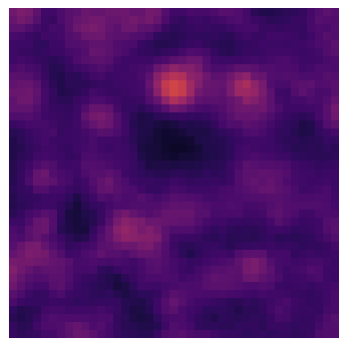

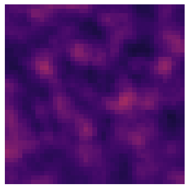

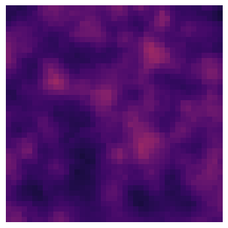

10/41

10/41